# Project Description:

##### - Relationship between Ash, Water, Superplastic, Coarseagg, Fineagg and Age

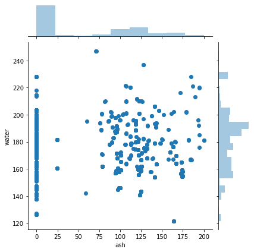

```python
# plotting between 'ash' and 'water':
sns.jointplot(concrete_data['ash'], concrete_data['water'])
```

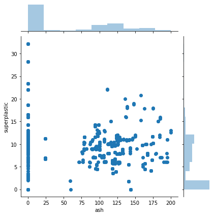

```python
# plotting between 'ash' and 'superplastic':
sns.jointplot(concrete_data['ash'], concrete_data['superplastic'])
```

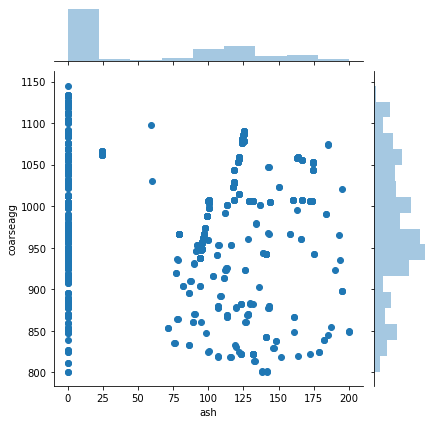

```python
# plotting between 'ash' and 'coarseagg':
sns.jointplot(concrete_data['ash'], concrete_data['coarseagg'])
```

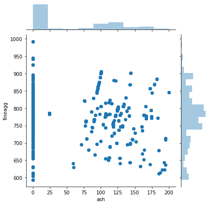

```python
# plotting between 'ash' and 'fineagg':
sns.jointplot(concrete_data['ash'], concrete_data['fineagg'])
```

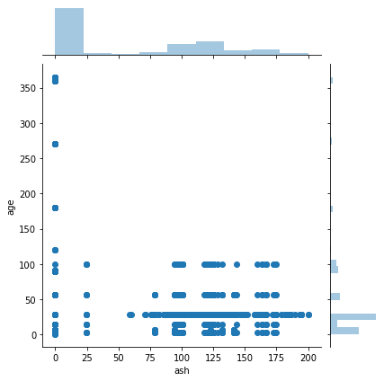

```python
# plotting between 'ash' and 'age':
sns.jointplot(concrete_data['ash'], concrete_data['age'])
```

##### - Relationship between Water, Superplastic, Coarseagg, Fineagg and Age

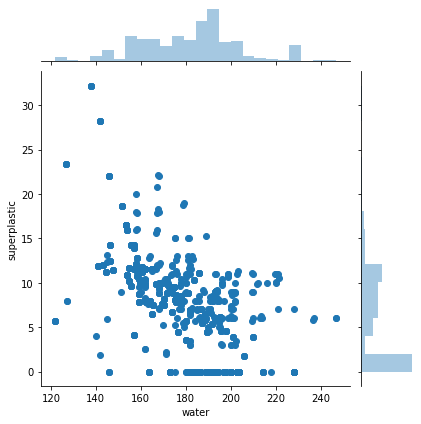

```python
# plottingg between 'water' and 'superplastic':
sns.jointplot(concrete_data['water'], concrete_data['superplastic'])
```

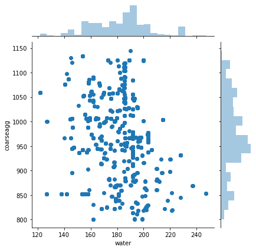

```python
# plotting between 'water' and 'coarseagg':
sns.jointplot(concrete_data['water'], concrete_data['coarseagg'])
```

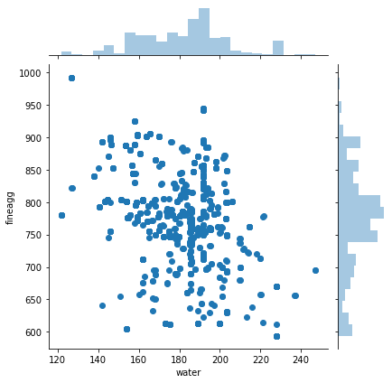

```python
# plotting between 'water' and 'fineagg':
sns.jointplot(concrete_data['water'], concrete_data['fineagg'])
```

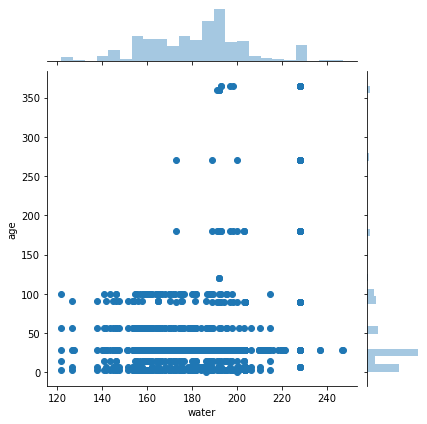

```python
# plotting between 'water' and 'age':
sns.jointplot(concrete_data['water'], concrete_data['age'])
```

##### - Relationship between Superplastic, Coarseagg, Fineagg and Age

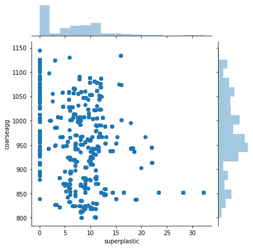

```python
# plotting between 'superplastic' and 'coarseagg':
sns.jointplot(concrete_data['superplastic'], concrete_data['coarseagg'])
```

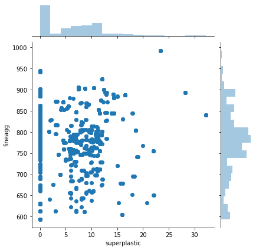

```python
# plotting between 'superplastic' and 'fineagg':
sns.jointplot(concrete_data['superplastic'], concrete_data['fineagg'])
```

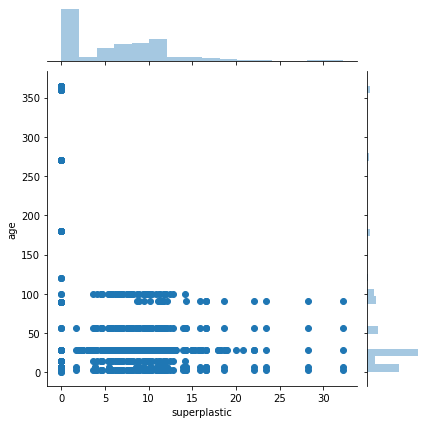

```python
# plotting between 'superplastic' and 'age':
sns.jointplot(concrete_data['superplastic'], concrete_data['age'])
```

##### - Relationship between Coarseagg, Fineagg and Age

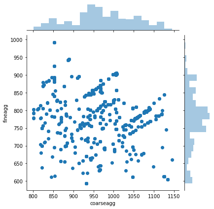

```python
# plotting between 'coarseagg' and 'fineagg':
sns.jointplot(concrete_data['coarseagg'], concrete_data['fineagg'])
```

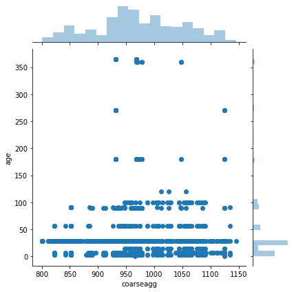

```python
# plotting between 'coarseagg' and 'age':
sns.jointplot(concrete_data['coarseagg'], concrete_data['age'])
```

##### - Relationship between Fineagg and Age

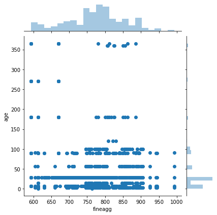

```python
# plotting between 'fineagg' and 'age':
sns.jointplot(concrete_data['fineagg'], concrete_data['age'])
```

### Analysis with the Predictor Variables

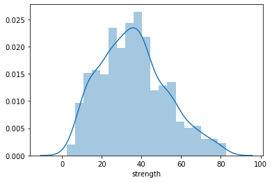

```python
# plotting of 'Strength':
sns.distplot(concrete_data['strength'])
```

From the plot it is clear that **strength** does have a normal distribution.

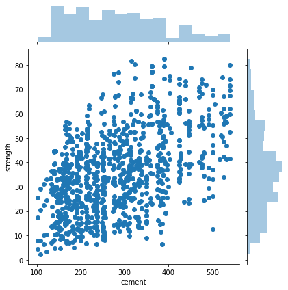

```python
# plotting between 'cement' and 'strength':
sns.jointplot(concrete_data['cement'], concrete_data['strength'])
```

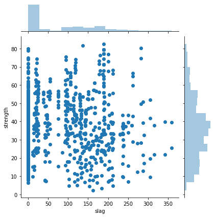

```python
# plotting between 'slag' and 'strength':
sns.jointplot(concrete_data['slag'], concrete_data['strength'])
```

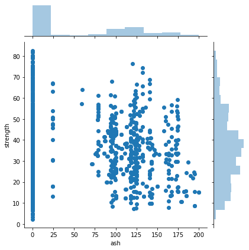

```python
# plotting between 'ash' and 'strength':
sns.jointplot(concrete_data['ash'], concrete_data['strength'])
```

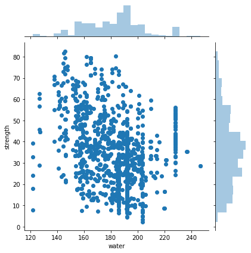

```python
# plotting between 'water' and 'strength':
sns.jointplot(concrete_data['water'], concrete_data['strength'])
```

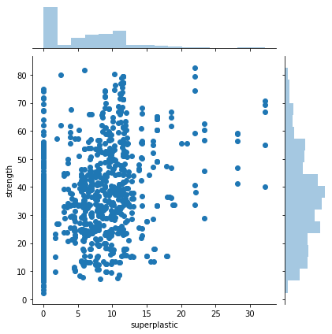

```python
# plotting between 'superplastic' and 'strength':
sns.jointplot(concrete_data['superplastic'], concrete_data['strength'])
```

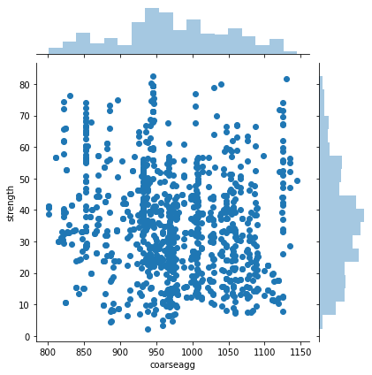

```python
# plotting between 'coarseagg' and 'strength':
sns.jointplot(concrete_data['coarseagg'], concrete_data['strength'])
```

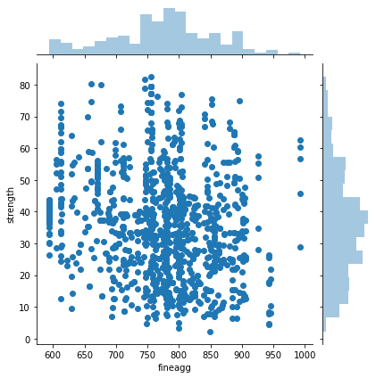

```python
# plotting between 'fineagg' and 'strength':
sns.jointplot(concrete_data['fineagg'], concrete_data['strength'])
```

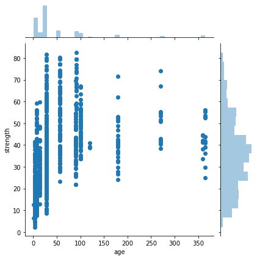

```python
# plotting between 'age' and 'strength':
sns.jointplot(concrete_data['age'], concrete_data['strength'])
```

#### Relationship between strength and predictor variables:

- cement vs strength: It somehow seems that the two are linearly related. The relationship is positive but what we can see is that, for a given value of cement we have a multiple values of strength (which one should we pick we don't know). Hence, cement though it has positive relationship with the strength, it is not a very good predictor. It is a weak predictor.
- slag vs strength: There is no particular trend.
- ash vs strength: There is also no particular trend.
- water vs strength: There is no particular trend.
- superplastic vs strength: For a given value of age, we have different values of strength. Hence, it is not a good predictor.
- coarseagg vs strength: There is no particular trend.
- fineagg vs strength: There is no particular trend.
- strength vs age: For a given value of age, we have different values of strength. Hence, It is not a good predictor.

Hence, we can see that none of the independent attributes are a good predictors of the strength attribute.

### Treating the outliers

From the above analysis we know that the independent attributes **slag**, **water**, **superplastic**, **fineagg** and **age** does have outliers in them. We will replace those outliers with the median of the respective attributes.

```python
for col_name in concrete_data.columns[:-1]:
    iq_25 = concrete_data[col_name].quantile(0.25)
    iq_75 = concrete_data[col_name].quantile(0.75)
    iqr = iq_75 - iq_25
    cut_off = 1.5 * iqr
    low_lim = iq_25 - cut_off
    upp_lim = iq_75 + cut_off

    concrete_data.loc[(concrete_data[col_name] < low_lim) | (concrete_data[col_name] > upp_lim), col_name] = concrete_data[col_name].median()
```

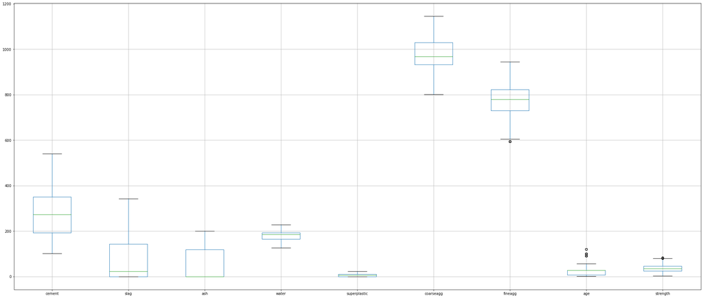

```python
# again checking for outliers in dataset
concrete_data.boxplot(figsize = (35,15))
```

### Treating missing values

As we already know that none of the independent attributes does have any missing values with them, so there is no need to do such an operation.

## Feature Engineering

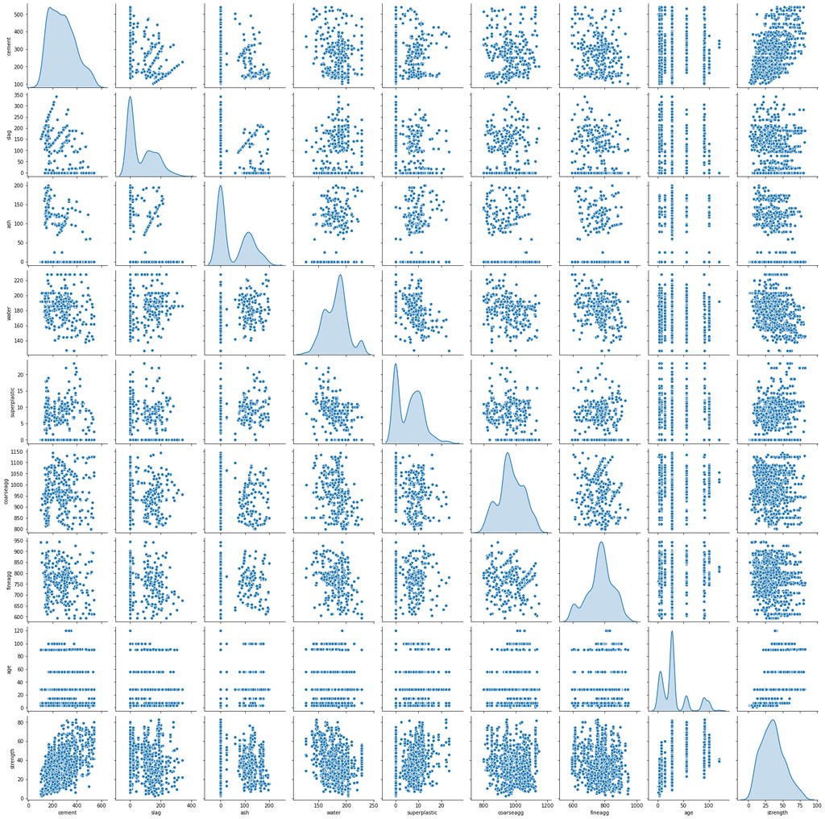

```python
sns.pairplot(concrete_data , diag_kind = 'kde')
```

```python
corr = concrete_data.corr()
corr
```

|  | cement | slag | ash | water | superplastic | coarseagg | fineagg | age | strength |
| --- | --- | --- | --- | --- | --- | --- | --- | --- | --- |
| cement | 1.000000 | -0.275046 | -0.397467 | -0.091614 | 0.013336 | -0.109349 | -0.238698 | -0.031962 | 0.497832 |
| slag | -0.275046 | 1.000000 | -0.320468 | 0.098880 | 0.061195 | -0.283882 | -0.282383 | -0.028971 | 0.137800 |
| ash | -0.397467 | -0.320468 | 1.000000 | -0.248011 | 0.447492 | -0.009961 | 0.091729 | 0.057928 | -0.105755 |
| water | -0.091614 | 0.098880 | -0.248011 | 1.000000 | -0.658056 | -0.156928 | -0.426299 | -0.040304 | -0.307711 |
| superplastic | 0.013336 | 0.061195 | 0.447492 | -0.658056 | 1.000000 | -0.224503 | 0.156591 | 0.062013 | 0.346260 |
| coarseagg | -0.109349 | -0.283882 | -0.009961 | -0.156928 | -0.224503 | 1.000000 | -0.161377 | 0.018078 | -0.164935 |
| fineagg | -0.238698 | -0.282383 | 0.091729 | -0.426299 | 0.156591 | -0.161377 | 1.000000 | 0.051532 | -0.182186 |
| age | -0.031962 | -0.028971 | 0.057928 | -0.040304 | 0.062013 | 0.018078 | 0.051532 | 1.000000 | 0.499850 |
| strength | 0.497832 | 0.137800 | -0.105755 | -0.307711 | 0.346260 | -0.164935 | -0.182186 | 0.499850 | 1.000000 |

```
(9.5, -0.5)
```

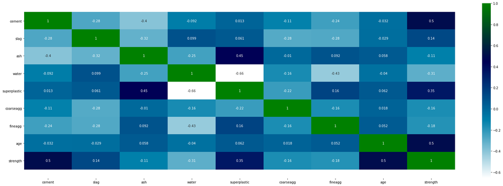

```python
# plotting a heatmap
plt.figure(figsize = (30,10))
ax = sns.heatmap(corr, annot = True, cmap = "ocean_r")
bottom, top = ax.get_ylim()
ax.set_ylim(bottom + 0.5, top - 0.5)
```

### Complexity of the model

```python
X = concrete_data.drop('strength', axis = 1)
y = concrete_data['strength']
```

X represents the independent variables whereas y the dependent variables.

```python
X_train, X_test, y_train, y_test = train_test_split(X, y, test_size = 0.3, random_state = 1)
```

```python
print('The size for training dataset is:', (X_train.shape) ,'and:', (y_train.shape))
print('The size for test dataset is:', (X_test.shape) ,'and', (y_test.shape))
```

```
The size for training dataset is: (721, 8) and: (721,)
The size for test dataset is: (309, 8) and (309,)
```

The theory that a simple linear model can not be used can be further proved by testing the parameters on a model based on **Linear Regression**.

```python
lin_model = LinearRegression()
lin_model.fit(X_train, y_train)
```

```
LinearRegression()
```

```python
pred_lin = lin_model.predict(X_test)
print('Accuracy of training data on using Linear Regression:', lin_model.score(X_train, y_train))
print('Accuracy of testing data on using Linear Regression:', lin_model.score(X_test, y_test))
acc_lin = metrics.r2_score(y_test, pred_lin)
print('Accuracy on using Linear Regression:', acc_lin)
mse_lin = metrics.mean_squared_error(y_test, pred_lin)
print('MSE:', mse_lin)
rmse_lin = np.sqrt(metrics.mean_squared_error(y_test, pred_lin))
print('RMSE:', rmse_lin)
```

```
Accuracy of training data on using Linear Regression: 0.7214971210103256
Accuracy of testing data on using Linear Regression: 0.6981381588376172
Accuracy on using Linear Regression: 0.6981381588376172
MSE: 87.85373713247506
RMSE: 9.373032440596536
```

Here, we can see that the model can't be a simple Linear model in terms of parameters as the model performs a measly 72.1% on the training data ans 69.8% on test data (a fine case of Undefitting). Hence, if one has to use a simple model like Linear Regression then one needs to use a parameter based on quadratic or higher degree.

### Explore for gaussians. If data is likely to be a mix of gaussians, explore individual clusters and present your findings in terms of the independent attributes and their suitability to predict strength

The diagonal of the paiplot gives us the same information that we have got using distplot:

- **cement** have an almost normal curve.
- **slag** has two gausssians and rightly skewed.
- **ash** has two gaussians and rightly skewed.
- **water** has three guassians and slighly left skewed.
- **superplastic** has also two gaussians and is rightly skewed.
- **coarseagg** has three guassians and is almost normal.
- **fineagg** has almost two guassians and looks like it is also normal.
- **age** has multiple guassians (atleast 4) and is rightly skewed.
- **strength** is close to a normal curve.

As the data is a mix of gaussians we will try to explore each clusters to find whether there isn't any sort of predictability with **strength**.

```python
cluster_range = range(1,15)
cluster_error = []

for num_clusters in cluster_range:
    clusters = KMeans(num_clusters, n_init = 5)
    clusters.fit(concrete_data)
    labels = clusters.labels_
    centroids = clusters.cluster_centers_
    cluster_error.append(clusters.inertia_)

cluster_df = pd.DataFrame({"num_clusters": cluster_range, "cluster_errors": cluster_error})
cluster_df
```

|  | num_clusters | cluster_errors |
| --- | --- | --- |
| 0 | 1 | 3.709976e+07 |
| 1 | 2 | 2.774910e+07 |
| 2 | 3 | 2.141025e+07 |
| 3 | 4 | 1.869846e+07 |
| 4 | 5 | 1.668446e+07 |
| 5 | 6 | 1.470944e+07 |
| 6 | 7 | 1.365648e+07 |
| 7 | 8 | 1.228938e+07 |
| 8 | 9 | 1.138308e+07 |
| 9 | 10 | 1.055112e+07 |
| 10 | 11 | 9.724501e+06 |
| 11 | 12 | 9.080146e+06 |
| 12 | 13 | 8.839350e+06 |
| 13 | 14 | 8.377635e+06 |

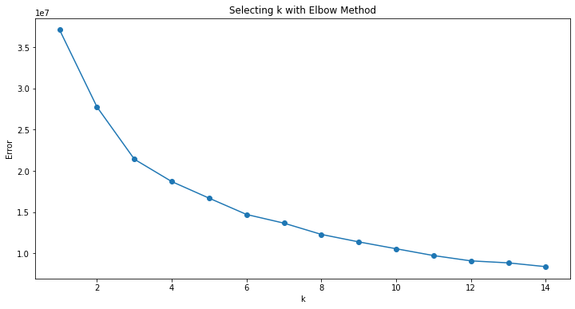

```python
# Elbow Plot
plt.figure(figsize = (12,6))
plt.plot(cluster_df.num_clusters, cluster_df.cluster_errors, marker = "o")
plt.xlabel('k')
plt.ylabel('Error')
plt.title('Selecting k with Elbow Method')
```

```python
concrete_df_z = concrete_data.apply(zscore)
concrete_df_z = pd.DataFrame(concrete_df_z, columns = concrete_data.columns)
```

```python
cluster = KMeans(n_clusters = 6, random_state = 1)
cluster.fit(concrete_df_z)
```

```
KMeans(n_clusters=6, random_state=1)
```

```python
# Creating a new column 'GROUP' which will hold the cluster id of each record
prediction = cluster.predict(concrete_df_z)
concrete_df_z['GROUP'] = prediction
```

```python
centroids = cluster.cluster_centers_
centroids
```

```
array([[ 0.29437105, -0.83136532, -0.77079977,  0.43585367, -0.98792456,
         0.5088548 ,  0.41831131, -0.25295932, -0.68922042],
       [-0.52847035,  0.25047012,  1.10117943,  0.4707871 ,  0.51065443,
        -1.14464266, -0.34207299, -0.2243148 , -0.27815339],
       [-0.84995576,  1.42084044, -0.84714393,  0.5969756 , -0.74107586,
        -0.04746442, -0.18749094, -0.1648694 , -0.54412831],
       [ 1.01509268,  0.48811529, -0.50838886, -1.03076017,  1.03518903,
        -0.61291914,  0.18124555,  0.08216463,  1.20471909],
       [ 1.4291599 , -0.44054978, -0.69991583,  1.28868268, -1.0044499 ,
         0.18268458, -1.6298192 ,  0.14934337,  0.67689116],
       [-0.60396309, -0.65588464,  1.10862567, -0.61741396,  0.49398255,
         0.62686765,  0.43267965,  0.27851339, -0.13328847]])
```

```python
centroid_df = pd.DataFrame(centroids, columns = list(concrete_data))
centroid_df
```

|  | cement | slag | ash | water | superplastic | coarseagg | fineagg | age | strength |
| --- | --- | --- | --- | --- | --- | --- | --- | --- | --- |
| 0 | 0.294371 | -0.831365 | -0.770800 | 0.435854 | -0.987925 | 0.508855 | 0.418311 | -0.252959 | -0.689220 |
| 1 | -0.528470 | 0.250470 | 1.101179 | 0.470787 | 0.510654 | -1.144643 | -0.342073 | -0.224315 | -0.278153 |
| 2 | -0.849956 | 1.420840 | -0.847144 | 0.596976 | -0.741076 | -0.047464 | -0.187491 | -0.164869 | -0.544128 |
| 3 | 1.015093 | 0.488115 | -0.508389 | -1.030760 | 1.035189 | -0.612919 | 0.181246 | 0.082165 | 1.204719 |
| 4 | 1.429160 | -0.440550 | -0.699916 | 1.288683 | -1.004450 | 0.182685 | -1.629819 | 0.149343 | 0.676891 |
| 5 | -0.603963 | -0.655885 | 1.108626 | -0.617414 | 0.493983 | 0.626868 | 0.432680 | 0.278513 | -0.133288 |

```
array([[<matplotlib.axes._subplots.AxesSubplot object at 0x000001F4A550AF48>,
      dtype=object)
```

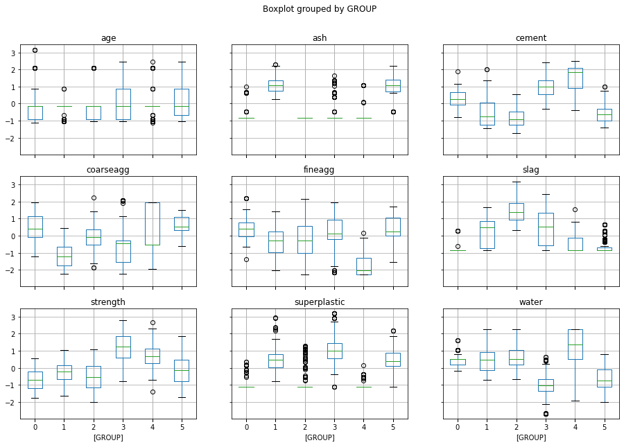

```python
concrete_df_z.boxplot(by = 'GROUP', layout = (3,3), figsize = (15,10))
```

- Here, none of the dimensions are good predictor of target variable.
- For all the dimensions (variables) every cluster have a similar range of values except in one case.
- We can see that the body of the cluster are overlapping.
- So in k means, though, there are clusters in datasets on different dimensions but we can not see any distinct characteristics of these clusters which tell us to break data into different clusters and build separate models for them.

## Model creation

#### Scaling of the features

As all the predictors in the same scale apart from **age**, so we will scale the datasets.

```python
scaled_X_train = X_train.copy()
scaled_X_test = X_test.copy()

num_cols = ['cement', 'slag', 'ash', 'water', 'superplastic', 'coarseagg', 'fineagg', 'age']

for i in num_cols:
    scale = StandardScaler().fit(scaled_X_train[[i]])
    scaled_X_train[i] = scale.transform(scaled_X_train[[i]])
    scaled_X_test[i] = scale.transform(scaled_X_test[[i]])
```

##### Polynomial Featurization

As we will first try to develop some simple models, for that we need to have variables in higher degree as with simple parameters the model is performing very poorly.

```
Best degree 3 with RMSE 6.016097316280968
```

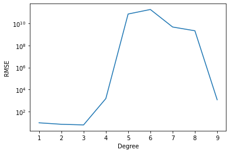

```python
rmses = []
degrees = np.arange(1,10)
min_rmse, min_deg = 1e10, 0

for deg in degrees:
    poly_features = PolynomialFeatures(degree = deg, include_bias = False)
    poly_X_train = poly_features.fit_transform(scaled_X_train)

    poly_reg = LinearRegression()
    poly_reg.fit(poly_X_train, y_train)

    poly_X_test = poly_features.fit_transform(scaled_X_test)
    poly_predict = poly_reg.predict(poly_X_test)
    poly_mse = mean_squared_error(y_test, poly_predict)
    poly_rmse = np.sqrt(poly_mse)
    rmses.append(poly_rmse)

    if min_rmse > poly_rmse:
        min_rmse = poly_rmse
        min_deg = deg

print('Best degree {} with RMSE {}'.format(min_deg, min_rmse))

fig = plt.figure()
ax = fig.add_subplot(111)
ax.plot(degrees, rmses)
ax.set_yscale('log')
ax.set_xlabel('Degree')
ax.set_ylabel('RMSE')
```

Thus, for degree = 3, Linear Regression yields the best accuracy as it is giving the least error.

So, now we will apply degree = 3 to all the datasets available i.e., train and test.

```python
poly = PolynomialFeatures(degree = 3)
poly_X_train = poly.fit_transform(scaled_X_train)
poly_X_test = poly.transform(scaled_X_test)
```

##### Linear Regression (after applying Polynomial Featurization)

```python
lin_model_poly = LinearRegression()
lin_model_poly.fit(poly_X_train, y_train)
```

```
LinearRegression()
```

```python
pred_lin_poly = lin_model_poly.predict(poly_X_test)
print('Accuracy of training data on using Linear Regression:', lin_model_poly.score(poly_X_train, y_train))
print('Accuracy of testing data on using Linear Regression:', lin_model_poly.score(poly_X_test, y_test))
acc_lin_poly = metrics.r2_score(y_test, pred_lin_poly)
print('Accuracy on using Linear Regression:', acc_lin_poly)
mse_lin_poly = metrics.mean_squared_error(y_test, pred_lin_poly)
print('MSE:', mse_lin_poly)
rmse_lin_poly = np.sqrt(metrics.mean_squared_error(y_test, pred_lin_poly))
print('RMSE:', rmse_lin_poly)
```

```
Accuracy of training data on using Linear Regression: 0.9419719814677286
Accuracy of testing data on using Linear Regression: 0.8756408680570991
Accuracy on using Linear Regression: 0.8756408680570991
MSE: 36.19342691896327
RMSE: 6.016097316280985
```

The performance of the model has improved by a lot as it is now able to predict around 94% in training dataset and 87.5% in test data with an R2 score of 0.876 and RMSE of 6.01

[output not shown]

[output cut: 110 more lines]

[output not shown]

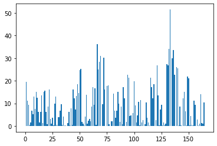

```python
results = permutation_importance(lin_model_poly, poly_X_train, y_train, scoring = 'neg_root_mean_squared_error', random_state = 1)
importance = results.importances_mean

for i, v in enumerate(importance):
    print('Feature: %0d, Score:%.5f' % (i,v))

plt.bar([x for x in range(len(importance))], importance)
plt.show()
```

```python
#Store the accuracy results for each model in a dataframe for final comparison
results = pd.DataFrame({'Method': ['Linear Regressor (with Polynomial Features)'], 'Accuracy': acc_lin_poly, 'MSE': mse_lin_poly, 'RMSE': rmse_lin_poly},index={'1'})
results = results[['Method', 'Accuracy', 'MSE', 'RMSE']]
results
```

|  | Method | Accuracy | MSE | RMSE |
| --- | --- | --- | --- | --- |
| 1 | Linear Regressor (with Polynomial Features) | 0.875641 | 36.193427 | 6.016097 |

##### Ridge Regression

```python
ridge = Ridge(alpha = 0.3)
ridge.fit(poly_X_train, y_train)
```

```
Ridge(alpha=0.3)
```

```python
pred_ridge = ridge.predict(poly_X_test)
print('Accuracy of training data on using Ridge:', ridge.score(poly_X_train, y_train))
print('Accuracy of test data on using Ridge:', ridge.score(poly_X_test, y_test))
acc_ridge = metrics.r2_score(y_test, pred_ridge)
print('Accuracy on using Ridge:', acc_ridge)
mse_ridge = metrics.mean_squared_error(y_test, pred_ridge)
print('MSE:', mse_ridge)
rmse_ridge = np.sqrt(metrics.mean_squared_error(y_test, pred_ridge))
print('RMSE:', rmse_ridge)
```

```
Accuracy of training data on using Ridge: 0.9399140683686302
Accuracy of test data on using Ridge: 0.8808335376897718
Accuracy on using Ridge: 0.8808335376897718
MSE: 34.68215463900916
RMSE: 5.889155681335752
```

The performance of the model based on Ridge (and polynomial features) is around 94% in training dataset and 88% in test data with an R2 score of 0.88 and RMSE of 5.89

[output not shown]

[output cut: 110 more lines]

[output not shown]

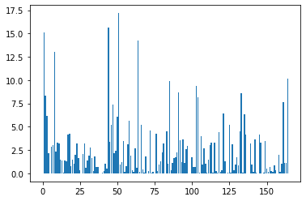

```python
results_ridge = permutation_importance(ridge, poly_X_train, y_train, scoring = 'neg_root_mean_squared_error', random_state = 1)
importance = results_ridge.importances_mean

for i, v in enumerate(importance):
    print('Feature: %0d, Score:%.5f' % (i,v))

plt.bar([x for x in range(len(importance))], importance)
plt.show()
```

```python
#Store the accuracy results for each model in a dataframe for final comparison
tempResultsDf = pd.DataFrame({'Method':['Ridge'], 'Accuracy': [acc_ridge], 'MSE': [mse_ridge], 'RMSE': [rmse_ridge]},index={'2'})
results = pd.concat([results, tempResultsDf])
results = results[['Method', 'Accuracy', 'MSE', 'RMSE']]
results
```

|  | Method | Accuracy | MSE | RMSE |
| --- | --- | --- | --- | --- |
| 1 | Linear Regressor (with Polynomial Features) | 0.875641 | 36.193427 | 6.016097 |
| 2 | Ridge | 0.880834 | 34.682155 | 5.889156 |

##### Lasso Regression

```python
lasso = Lasso(alpha = 0.01)
lasso.fit(poly_X_train, y_train)
```

```
Lasso(alpha=0.01)
```

```python
pred_lasso = lasso.predict(poly_X_test)
print('Accuracy of training data on using Lasso:', lasso.score(poly_X_train, y_train))
print('Accuracy of test data on using Lasso:', lasso.score(poly_X_test, y_test))
acc_lasso = metrics.r2_score(y_test, pred_lasso)
print('Accuracy on using Lasso:', acc_lasso)
mse_lasso = metrics.mean_squared_error(y_test, pred_lasso)
print('MSE:', mse_lasso)
rmse_lasso = np.sqrt(metrics.mean_squared_error(y_test, pred_lasso))
print('RMSE:', rmse_lasso)
```

```
Accuracy of training data on using Lasso: 0.9329678365345019
Accuracy of test data on using Lasso: 0.8833101238962114
Accuracy on using Lasso: 0.8833101238962114
MSE: 33.96137008164797
RMSE: 5.8276384652488495
```

The performance of the model based on Lasso (and polynomial features) is around 93.29% on training dataset and 88.33% on test data with an R2 score of 0.88 and RMSE of 5.82

[output not shown]

[output cut: 110 more lines]

[output not shown]

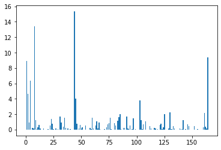

```python
results_lasso = permutation_importance(lasso, poly_X_train, y_train, scoring = 'neg_root_mean_squared_error', random_state = 1)
importance = results_lasso.importances_mean

for i, v in enumerate(importance):
    print('Feature: %0d, Score:%.5f' % (i,v))

plt.bar([x for x in range(len(importance))], importance)
plt.show()
```

```python
#Store the accuracy results for each model in a dataframe for final comparison
tempResultsDf = pd.DataFrame({'Method':['Lasso'], 'Accuracy': [acc_lasso], 'MSE': [mse_lasso], 'RMSE': [rmse_lasso]},index={'3'})
results = pd.concat([results, tempResultsDf])
results = results[['Method', 'Accuracy', 'MSE', 'RMSE']]
results
```

|  | Method | Accuracy | MSE | RMSE |
| --- | --- | --- | --- | --- |
| 1 | Linear Regressor (with Polynomial Features) | 0.875641 | 36.193427 | 6.016097 |
| 2 | Ridge | 0.880834 | 34.682155 | 5.889156 |
| 3 | Lasso | 0.883310 | 33.961370 | 5.827638 |

##### KNN Regressor

```python
knn_model = KNeighborsRegressor()
knn_model.fit(scaled_X_train, y_train)
```

```
KNeighborsRegressor()
```

```python
pred_knn = knn_model.predict(scaled_X_test)
print('Performance on training data using KNN Regression:',knn_model.score(scaled_X_train,y_train))
print('Performance on test data using KNN Regression:',knn_model.score(scaled_X_test,y_test))
acc_K=metrics.r2_score(y_test, pred_knn)
print('Accuracy KNNR:',acc_K)
mse_K = metrics.mean_squared_error(y_test, pred_knn)
print('MSE: ', mse_K)
rmse_K = np.sqrt(metrics.mean_squared_error(y_test, pred_knn))
print('RMSE: ', rmse_K)
```

```
Performance on training data using KNN Regression: 0.8549394457576097
Performance on test data using KNN Regression: 0.7830973329354318
Accuracy KNNR: 0.7830973329354318
MSE:  63.12725656957929
RMSE:  7.945266299475386
```

The model based on KNN Regressor (with scaled variables) performs poorly as it has an accuracy of just 85.5% on training dataset and 78.3% on test data with an R2 score of 0.78 and RMSE of 7.94

```
              0         1
0        cement  4.674895
1          slag  1.920255
2           ash  1.932915
3         water  2.712162
4  superplastic  2.991876
5     coarseagg  1.606928
6       fineagg  2.000589
7           age  7.021323
```

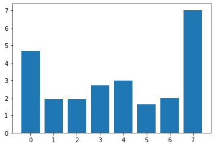

```python
results_knn = permutation_importance(knn_model, scaled_X_train, y_train, scoring = 'neg_root_mean_squared_error', random_state = 1)
importance = results_knn.importances_mean

print(pd.DataFrame(list(zip(X_train.columns, importance))))

plt.bar([x for x in range(len(importance))], importance)
plt.show()
```

Thus we can see that the top two most important feature for the model is **age** and **cement**.

```python
#Store the accuracy results for each model in a dataframe for final comparison
tempResultsDf = pd.DataFrame({'Method':['KNN Regressor'], 'Accuracy': [acc_K], 'MSE': [mse_K], 'RMSE': [rmse_K]},index={'4'})
results = pd.concat([results, tempResultsDf])
results = results[['Method', 'Accuracy', 'MSE', 'RMSE']]
results
```

|  | Method | Accuracy | MSE | RMSE |
| --- | --- | --- | --- | --- |
| 1 | Linear Regressor (with Polynomial Features) | 0.875641 | 36.193427 | 6.016097 |
| 2 | Ridge | 0.880834 | 34.682155 | 5.889156 |
| 3 | Lasso | 0.883310 | 33.961370 | 5.827638 |
| 4 | KNN Regressor | 0.783097 | 63.127257 | 7.945266 |

##### Support Vector Machine Regressor

```python
svr_model = SVR()
svr_model.fit(scaled_X_train, y_train)
```

```
SVR()
```

```python
pred_svr = svr_model.predict(scaled_X_test)
print('Performance on training data using SVM Regressor:',svr_model.score(scaled_X_train,y_train))
print('Performance on test data using SVM Regressor:',svr_model.score(scaled_X_test,y_test))
acc_svr = metrics.r2_score(y_test, pred_svr)
print('Accuracy SVR: ',acc_svr)
mse_svr = metrics.mean_squared_error(y_test, pred_svr)
print('MSE: ', mse_svr)
rmse_svr = np.sqrt(metrics.mean_squared_error(y_test, pred_svr))
print('RMSE: ', rmse_svr)
```

```
Performance on training data using SVM Regressor: 0.7099909546494112
Performance on test data using SVM Regressor: 0.7018429917527607
Accuracy SVR:  0.7018429917527607
MSE:  86.7754841946628
RMSE:  9.315335967889874
```

The performance of the model based on SVR is quite poor as it just predicts only 71% on training dataset and 70% on test data (a fine case of Underfitting) with an R2 score of 0.70 and RMSE of 9.31

```
              0         1
0        cement  3.569966
1          slag  0.771550
2           ash  0.599138
3         water  1.526937
4  superplastic  1.243345
5     coarseagg  0.543727
6       fineagg  0.770044
7           age  5.162477
```

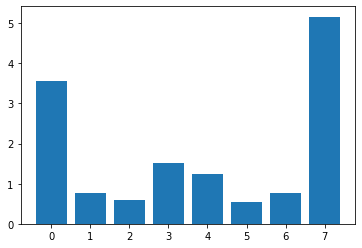

```python
results_svr = permutation_importance(svr_model, scaled_X_train, y_train, scoring = 'neg_root_mean_squared_error', random_state = 1)
importance = results_svr.importances_mean

print(pd.DataFrame(zip(X_train.columns, importance)))

plt.bar([x for x in range(len(importance))], importance)
plt.show()
```

Thus we can see that the top two most important feature for the model is **age** and **cement**.

```python
#Store the accuracy results for each model in a dataframe for final comparison
tempResultsDf = pd.DataFrame({'Method':['SVM Regressor'], 'Accuracy': [acc_svr], 'MSE': [mse_svr], 'RMSE': [rmse_svr]},index={'5'})
results = pd.concat([results, tempResultsDf])
results = results[['Method', 'Accuracy', 'MSE', 'RMSE']]
results
```

|  | Method | Accuracy | MSE | RMSE |
| --- | --- | --- | --- | --- |
| 1 | Linear Regressor (with Polynomial Features) | 0.875641 | 36.193427 | 6.016097 |
| 2 | Ridge | 0.880834 | 34.682155 | 5.889156 |
| 3 | Lasso | 0.883310 | 33.961370 | 5.827638 |
| 4 | KNN Regressor | 0.783097 | 63.127257 | 7.945266 |
| 5 | SVM Regressor | 0.701843 | 86.775484 | 9.315336 |

##### Decision Tree Regressor

```python
decision_model = DecisionTreeRegressor(random_state = 1)
decision_model.fit(X_train, y_train)
```

```
DecisionTreeRegressor(random_state=1)
```

```python
pred_decision = decision_model.predict(X_test)
print('Performance on training data using Decision Tree Regressor:',decision_model.score(X_train,y_train))
print('Performance on test data using Decision Tree Regressor:',decision_model.score(X_test,y_test))
acc_dt = metrics.r2_score(y_test, pred_decision)
print('Accuracy on using Decision Tree Regressor: ',acc_dt)
mse_dt = metrics.mean_squared_error(y_test, pred_decision)
print('MSE: ', mse_dt)
rmse_dt = np.sqrt(metrics.mean_squared_error(y_test, pred_decision))
print('RMSE: ', rmse_dt)
```

```
Performance on training data using Decision Tree Regressor: 0.9917907420889983
Performance on test data using Decision Tree Regressor: 0.851768008070478
Accuracy on using Decision Tree Regressor:  0.851768008070478
MSE:  43.141373561668466
RMSE:  6.568209311651728
```

The performance of the model based on Decision Tree Regressor is around 99% on training dataset and just 85% on test data (a fine example of Overfitting) with an R2 score of 0.85 and RMSE of 6.56

```python
text_representation = tree.export_text(decision_model)
print(text_representation)
```

[output not shown]

[output cut: 1161 more lines]

[output not shown]

```
              0          1
0        cement  35.153003
1          slag   9.623100
2           ash   1.252015
3         water  12.658396
4  superplastic   1.876469
5     coarseagg   3.614248
6       fineagg   2.970216
7           age  32.852553
```

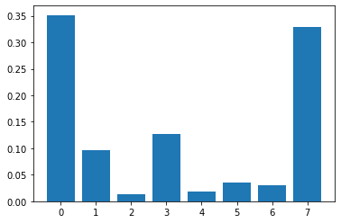

```python
importance = decision_model.feature_importances_

print(pd.DataFrame(zip(X_train.columns, importance*100)))

plt.bar([x for x in range(len(importance))], importance)
plt.show()
```

The top two important attribute for this model are **age** and **cement**.

```python
#Store the accuracy results for each model in a dataframe for final comparison
tempResultsDf = pd.DataFrame({'Method':['Decision Tree Regressor'], 'Accuracy': [acc_dt], 'MSE': [mse_dt], 'RMSE': [rmse_dt]},index={'6'})
results = pd.concat([results, tempResultsDf])
results = results[['Method', 'Accuracy', 'MSE', 'RMSE']]
results
```

|  | Method | Accuracy | MSE | RMSE |
| --- | --- | --- | --- | --- |
| 1 | Linear Regressor (with Polynomial Features) | 0.875641 | 36.193427 | 6.016097 |
| 2 | Ridge | 0.880834 | 34.682155 | 5.889156 |
| 3 | Lasso | 0.883310 | 33.961370 | 5.827638 |
| 4 | KNN Regressor | 0.783097 | 63.127257 | 7.945266 |
| 5 | SVM Regressor | 0.701843 | 86.775484 | 9.315336 |
| 6 | Decision Tree Regressor | 0.851768 | 43.141374 | 6.568209 |

##### Random Forest Regressor

```python
random_model = RandomForestRegressor(random_state = 1)
random_model.fit(X_train, y_train)
```

```
RandomForestRegressor(random_state=1)
```

```python
pred_random = random_model.predict(X_test)
print('Performance on training data using Random Forest Regressor:',random_model.score(X_train,y_train))
print('Performance on test data using Random Forest Regressor:',random_model.score(X_test,y_test))
acc_random = metrics.r2_score(y_test, pred_random)
print('Accuracy on using Random Forest Regressor: ',acc_random)
mse_random = metrics.mean_squared_error(y_test, pred_random)
print('MSE: ', mse_random)
rmse_random = np.sqrt(metrics.mean_squared_error(y_test, pred_random))
print('RMSE: ', rmse_random)
```

```
Performance on training data using Random Forest Regressor: 0.9793124496937877
Performance on test data using Random Forest Regressor: 0.9026792766713222
Accuracy on using Random Forest Regressor:  0.9026792766713222
MSE:  28.32418039967045
RMSE:  5.322046636367484
```

The performance of the model based on Random Forest Regressor is around 97% on training dataset and 90% on test data with an R2 score of 0.9 and RMSE of 5.32

```
              0          1
0        cement  32.489354
1          slag   7.129563
2           ash   2.359062
3         water  13.040497
4  superplastic   4.287150
5     coarseagg   3.018405
6       fineagg   3.727960
7           age  33.948011
```

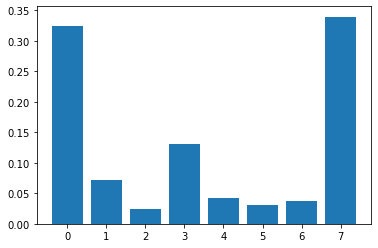

```python
importance = random_model.feature_importances_

print(pd.DataFrame(zip(X_train, importance*100)))

plt.bar([x for x in range(len(importance))], importance)
plt.show()
```

The top two most importnat feature for this model are **age** and **cement**.

```python
#Store the accuracy results for each model in a dataframe for final comparison
tempResultsDf = pd.DataFrame({'Method':['Random Forest Regressor'], 'Accuracy': [acc_random], 'MSE': [mse_random], 'RMSE': [rmse_random]},index={'7'})
results = pd.concat([results, tempResultsDf])
results = results[['Method', 'Accuracy', 'MSE', 'RMSE']]
results
```

|  | Method | Accuracy | MSE | RMSE |
| --- | --- | --- | --- | --- |
| 1 | Linear Regressor (with Polynomial Features) | 0.875641 | 36.193427 | 6.016097 |
| 2 | Ridge | 0.880834 | 34.682155 | 5.889156 |
| 3 | Lasso | 0.883310 | 33.961370 | 5.827638 |
| 4 | KNN Regressor | 0.783097 | 63.127257 | 7.945266 |
| 5 | SVM Regressor | 0.701843 | 86.775484 | 9.315336 |
| 6 | Decision Tree Regressor | 0.851768 | 43.141374 | 6.568209 |
| 7 | Random Forest Regressor | 0.902679 | 28.324180 | 5.322047 |

##### Bagging Regressor

```python
bagging_model = BaggingRegressor(base_estimator = decision_model, random_state = 1)
bagging_model.fit(X_train, y_train)
```

```
BaggingRegressor(base_estimator=DecisionTreeRegressor(random_state=1),
                 random_state=1)
```

```python
pred_bagg = bagging_model.predict(X_test)
print('Performance on training data using Bagging Regressor:',bagging_model.score(X_train,y_train))
print('Performance on test data using Bagging Regressor:',bagging_model.score(X_test,y_test))
acc_bagg = metrics.r2_score(y_test, pred_bagg)
print('Accuracy on using Bagging Regressor: ',acc_bagg)
mse_bagg = metrics.mean_squared_error(y_test, pred_bagg)
print('MSE: ', mse_bagg)
rmse_bagg = np.sqrt(metrics.mean_squared_error(y_test, pred_bagg))
print('RMSE: ', rmse_bagg)
```

```
Performance on training data using Bagging Regressor: 0.971055261286584
Performance on test data using Bagging Regressor: 0.886694891544593
Accuracy on using Bagging Regressor:  0.886694891544593
MSE:  32.97626879792707
RMSE:  5.74249673904366
```

The model based on Bagging (and a Decision Tree based model as an estimator) performs 97% on training data and 89% on test data with a R2 score of 0.89 and RMSE of 5.74

```
              0          1
0        cement  11.200766
1          slag   4.286063
2           ash   0.907889
3         water   4.339015
4  superplastic   2.957162
5     coarseagg   1.261296
6       fineagg   1.636254
7           age  11.886488
```

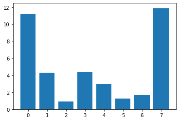

```python
results_bagg = permutation_importance(bagging_model, X_train, y_train, scoring = 'neg_root_mean_squared_error', random_state = 1)
importance = results_bagg.importances_mean

print(pd.DataFrame(zip(X_train.columns, importance)))

plt.bar([x for x in range(len(importance))], importance)
plt.show()
```

The top two important features for this model are as usual **age** and **cement**.

```python
#Store the accuracy results for each model in a dataframe for final comparison
tempResultsDf = pd.DataFrame({'Method':['Bagging Regressor'], 'Accuracy': [acc_bagg], 'MSE': [mse_bagg], 'RMSE': [rmse_bagg]},index = {'8'})
results = pd.concat([results, tempResultsDf])
results = results[['Method', 'Accuracy', 'MSE', 'RMSE']]
results
```

|  | Method | Accuracy | MSE | RMSE |
| --- | --- | --- | --- | --- |
| 1 | Linear Regressor (with Polynomial Features) | 0.875641 | 36.193427 | 6.016097 |
| 2 | Ridge | 0.880834 | 34.682155 | 5.889156 |
| 3 | Lasso | 0.883310 | 33.961370 | 5.827638 |
| 4 | KNN Regressor | 0.783097 | 63.127257 | 7.945266 |
| 5 | SVM Regressor | 0.701843 | 86.775484 | 9.315336 |
| 6 | Decision Tree Regressor | 0.851768 | 43.141374 | 6.568209 |
| 7 | Random Forest Regressor | 0.902679 | 28.324180 | 5.322047 |
| 8 | Bagging Regressor | 0.886695 | 32.976269 | 5.742497 |

##### Adaptive Boosting

```python
ada_model = AdaBoostRegressor(base_estimator = decision_model, random_state=1)
ada_model.fit(X_train, y_train)
```

```
AdaBoostRegressor(base_estimator=DecisionTreeRegressor(random_state=1),
                  random_state=1)
```

```python
pred_ada = ada_model.predict(X_test)
print('Performance on training data using AdaBoost Regressor:', ada_model.score(X_train, y_train))
print('Performance on test data using AdaBoost Regressor:', ada_model.score(X_test, y_test))
acc_ada = metrics.r2_score(y_test, pred_ada)
print('Accuracy on uisng AdaBoost Regressor:', acc_ada)
mse_ada = metrics.mean_squared_error(y_test, pred_ada)
print('MSE:', mse_ada)
rmse_ada = np.sqrt(metrics.mean_squared_error(y_test, pred_ada))
print('RMSE:', rmse_ada)
```

```
Performance on training data using AdaBoost Regressor: 0.9701040562927932
Performance on test data using AdaBoost Regressor: 0.8847924920587765
Accuracy on uisng AdaBoost Regressor: 0.8847924920587765
MSE: 33.529942305331325
RMSE: 5.790504494889139
```

The model based on Adaptive Boosting Regressor (and Decision Tree Regressor as a base model) performs correctly 97% on training data while 88% on test data with a R2 score of 0.88 and RMSE of 5.79

```
              0          1
0        cement  26.114840
1          slag   7.371589
2           ash   2.624611
3         water  18.001653
4  superplastic   6.631995
5     coarseagg   6.278498
6       fineagg   6.684173
7           age  26.292640
```

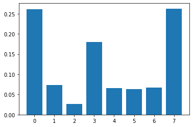

```python
importance = ada_model.feature_importances_

print(pd.DataFrame(zip(X_train.columns, importance*100)))

plt.bar([x for x in range(len(importance))], importance)
plt.show()
```

The top two most important features for this model are also **age** and **cement**.

```python
#Store the accuracy results for each model in a dataframe for final comparison
tempResultsDf = pd.DataFrame({'Method': ['AdaBoost Regressor'], 'Accuracy': [acc_ada], 'MSE': [mse_ada], 'RMSE': [rmse_ada]}, index = {'9'})
results = pd.concat([results, tempResultsDf])
results = results[['Method', 'Accuracy', 'MSE', 'RMSE']]
results
```

|  | Method | Accuracy | MSE | RMSE |
| --- | --- | --- | --- | --- |
| 1 | Linear Regressor (with Polynomial Features) | 0.875641 | 36.193427 | 6.016097 |
| 2 | Ridge | 0.880834 | 34.682155 | 5.889156 |
| 3 | Lasso | 0.883310 | 33.961370 | 5.827638 |
| 4 | KNN Regressor | 0.783097 | 63.127257 | 7.945266 |
| 5 | SVM Regressor | 0.701843 | 86.775484 | 9.315336 |
| 6 | Decision Tree Regressor | 0.851768 | 43.141374 | 6.568209 |
| 7 | Random Forest Regressor | 0.902679 | 28.324180 | 5.322047 |
| 8 | Bagging Regressor | 0.886695 | 32.976269 | 5.742497 |
| 9 | AdaBoost Regressor | 0.884792 | 33.529942 | 5.790504 |

##### Gradient Boosting Regressor

```python
grad_model = GradientBoostingRegressor(random_state = 1)
grad_model.fit(X_train, y_train)
```

```
GradientBoostingRegressor(random_state=1)
```

```python
pred_grad = grad_model.predict(X_test)
print('Performance on training data using Gradient Boosting:', grad_model.score(X_train, y_train))
print('Performance on test data using Gradient Boosting:', grad_model.score(X_test, y_test))
acc_grad = metrics.r2_score(y_test, pred_grad)
print('Accuracy on using Gradient Boosting Regressor:', acc_grad)
mse_grad = metrics.mean_squared_error(y_test, pred_grad)
print('MSE:', mse_grad)
rmse_grad = np.sqrt(metrics.mean_squared_error(y_test, pred_grad))
print('RMSE:', rmse_grad)
```

```
Performance on training data using Gradient Boosting: 0.9430469892492805
Performance on test data using Gradient Boosting: 0.8923964918396713
Accuracy on using Gradient Boosting Regressor: 0.8923964918396713
MSE: 31.316877562422107
RMSE: 5.596148457861184
```

The model based on Gradient Boosting Regression performs accurately about 94% on training data and 89.2% on test data with a R2 score of 0.89 and RMSe of 5.59

```
              0          1
0        cement  32.753812
1          slag   8.916588
2           ash   1.164150
3         water  13.215744
4  superplastic   3.327218
5     coarseagg   1.298417
6       fineagg   2.353490
7           age  36.970580
```

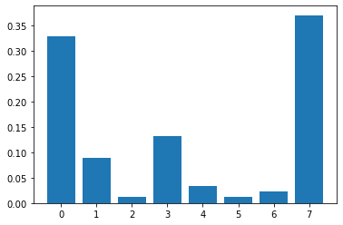

```python
importance = grad_model.feature_importances_

print(pd.DataFrame(zip(X_train.columns, importance*100)))

plt.bar([x for x in range(len(importance))], importance)
plt.show()
```

The top two most important feature of the model are as usual **age** and **cement**.

```python
#Store the accuracy results for each model in a dataframe for final comparison
tempResultsDf = pd.DataFrame({'Method': ['Gradient Boosting Regressor'], 'Accuracy': [acc_grad], 'MSE': [mse_grad], 'RMSE': [rmse_grad]}, index = {'10'})
results = pd.concat([results, tempResultsDf])
results = results[['Method', 'Accuracy', 'MSE', 'RMSE']]
results
```

|  | Method | Accuracy | MSE | RMSE |
| --- | --- | --- | --- | --- |
| 1 | Linear Regressor (with Polynomial Features) | 0.875641 | 36.193427 | 6.016097 |
| 2 | Ridge | 0.880834 | 34.682155 | 5.889156 |
| 3 | Lasso | 0.883310 | 33.961370 | 5.827638 |
| 4 | KNN Regressor | 0.783097 | 63.127257 | 7.945266 |
| 5 | SVM Regressor | 0.701843 | 86.775484 | 9.315336 |
| 6 | Decision Tree Regressor | 0.851768 | 43.141374 | 6.568209 |
| 7 | Random Forest Regressor | 0.902679 | 28.324180 | 5.322047 |
| 8 | Bagging Regressor | 0.886695 | 32.976269 | 5.742497 |
| 9 | AdaBoost Regressor | 0.884792 | 33.529942 | 5.790504 |
| 10 | Gradient Boosting Regressor | 0.892396 | 31.316878 | 5.596148 |

##### XG Boost

```python
xg_model = xgboost.XGBRegressor(random_state = 1)
xg_model.fit(X_train, y_train)
```

```
XGBRegressor(base_score=0.5, booster='gbtree', colsample_bylevel=1,
             colsample_bynode=1, colsample_bytree=1, gamma=0, gpu_id=-1,
             importance_type='gain', interaction_constraints='',
             learning_rate=0.300000012, max_delta_step=0, max_depth=6,
             min_child_weight=1, missing=nan, monotone_constraints='()',
             n_estimators=100, n_jobs=0, num_parallel_tree=1, random_state=1,
             reg_alpha=0, reg_lambda=1, scale_pos_weight=1, subsample=1,
             tree_method='exact', validate_parameters=1, verbosity=None)
```

```python
pred_xgb = xg_model.predict(X_test)
print('Performance on training data using XG Boost Regressor:', xg_model.score(X_train, y_train))
print('Performance on test data using XG Boost Regressor:', xg_model.score(X_test, y_test))
acc_xgb = metrics.r2_score(y_test, pred_xgb)
print('Accuracy on using XG Boost Regressor:', acc_xgb)
mse_xgb = metrics.mean_squared_error(y_test, pred_xgb)
print('MSE:', mse_xgb)
rmse_xgb = np.sqrt(metrics.mean_squared_error(y_test, pred_xgb))
print('RMSE:', rmse_xgb)
```

```
Performance on training data using XG Boost Regressor: 0.9911871605361094
Performance on test data using XG Boost Regressor: 0.8997129011718645
Accuracy on using XG Boost Regressor: 0.8997129011718645
MSE: 29.187513016877187
RMSE: 5.402546900941924
```

The model based on XG Boost Regressor performs accurately about 99.11% on training data and just 89.9% on test data with a R2 score of 0.899 and RMSE of 5.4

```
              0          1
0        cement  26.620506
1          slag  15.793046
2           ash   4.060322
3         water  15.481586
4  superplastic   4.441347
5     coarseagg   2.983513
6       fineagg   4.975091
7           age  25.644585
```

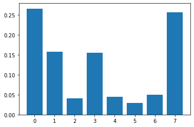

```python
importance = xg_model.feature_importances_

print(pd.DataFrame(zip(X_train.columns, importance*100)))

plt.bar([x for x in range(len(importance))], importance)
plt.show()
```

The two most important feature for this model are **cement** and **age**.

```python
#Store the accuracy results for each model in a dataframe for final comparison
tempResultsDf = pd.DataFrame({'Method': ['XG Boost Regressor'], 'Accuracy': [acc_xgb], 'MSE': [mse_xgb], 'RMSE': [rmse_xgb]}, index = {'11'})
results = pd.concat([results, tempResultsDf])
results = results[['Method', 'Accuracy', 'MSE', 'RMSE']]
results
```

|  | Method | Accuracy | MSE | RMSE |
| --- | --- | --- | --- | --- |
| 1 | Linear Regressor (with Polynomial Features) | 0.875641 | 36.193427 | 6.016097 |
| 2 | Ridge | 0.880834 | 34.682155 | 5.889156 |
| 3 | Lasso | 0.883310 | 33.961370 | 5.827638 |
| 4 | KNN Regressor | 0.783097 | 63.127257 | 7.945266 |
| 5 | SVM Regressor | 0.701843 | 86.775484 | 9.315336 |
| 6 | Decision Tree Regressor | 0.851768 | 43.141374 | 6.568209 |
| 7 | Random Forest Regressor | 0.902679 | 28.324180 | 5.322047 |
| 8 | Bagging Regressor | 0.886695 | 32.976269 | 5.742497 |
| 9 | AdaBoost Regressor | 0.884792 | 33.529942 | 5.790504 |
| 10 | Gradient Boosting Regressor | 0.892396 | 31.316878 | 5.596148 |
| 11 | XG Boost Regressor | 0.899713 | 29.187513 | 5.402547 |

##### Stacking Regressor

Here we will be using a model trained by Linear Regression (without polynomial features), KNN Regression and Support Vector Machine as these are three most poorly performing models.

```python
stack_model = StackingRegressor(regressors = [lin_model, knn_model], meta_regressor = svr_model)
stack_model.fit(scaled_X_train, y_train)
```

```
StackingRegressor(meta_regressor=SVR(),
                  regressors=[LinearRegression(), KNeighborsRegressor()])
```

```python
pred_stack = stack_model.predict(scaled_X_test)
print('Accuracy of training data on using Stack Regressor:', stack_model.score(scaled_X_train, y_train))
print('Accuracy of test data on using Stack Regressor:', stack_model.score(scaled_X_test, y_test))
acc_stack = metrics.r2_score(y_test, pred_stack)
print('Accuracy on using Stack Regressor:', acc_stack)
mse_stack = metrics.mean_squared_error(y_test, pred_stack)
print('MSE:', mse_stack)
rmse_stack = np.sqrt(metrics.mean_squared_error(y_test, pred_stack))
print('RMSE:', rmse_stack)
```

```
Accuracy of training data on using Stack Regressor: 0.8438260179099927
Accuracy of test data on using Stack Regressor: 0.7835500462424682
Accuracy on using Stack Regressor: 0.7835500462424682
MSE: 62.995499088343536
RMSE: 7.9369703973457995
```

```
              0         1
0        cement  5.579103
1          slag  2.240210
2           ash  1.573500
3         water  2.487564
4  superplastic  2.385895
5     coarseagg  1.124983
6       fineagg  1.406722
7           age  6.925920
```

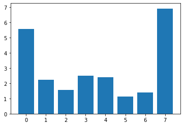

```python
results_stack = permutation_importance(stack_model, scaled_X_train, y_train, scoring = 'neg_root_mean_squared_error', random_state = 1)
importance = results_stack.importances_mean

print(pd.DataFrame(zip(X_train.columns, importance)))

plt.bar([x for x in range(len(importance))], importance)
plt.show()
```

The two most important features for this model are **age** and **cement**.

```python
#Store the accuracy results for each model in a dataframe for final comparison
tempResultsDf = pd.DataFrame({'Method': ['Stacking Regressor'], 'Accuracy': [acc_stack], 'MSE': [mse_stack], 'RMSE': [rmse_stack]}, index = {'12'})
results = pd.concat([results, tempResultsDf])
results = results[['Method', 'Accuracy', 'MSE', 'RMSE']]
results
```

|  | Method | Accuracy | MSE | RMSE |
| --- | --- | --- | --- | --- |
| 1 | Linear Regressor (with Polynomial Features) | 0.875641 | 36.193427 | 6.016097 |
| 2 | Ridge | 0.880834 | 34.682155 | 5.889156 |
| 3 | Lasso | 0.883310 | 33.961370 | 5.827638 |
| 4 | KNN Regressor | 0.783097 | 63.127257 | 7.945266 |
| 5 | SVM Regressor | 0.701843 | 86.775484 | 9.315336 |
| 6 | Decision Tree Regressor | 0.851768 | 43.141374 | 6.568209 |
| 7 | Random Forest Regressor | 0.902679 | 28.324180 | 5.322047 |
| 8 | Bagging Regressor | 0.886695 | 32.976269 | 5.742497 |
| 9 | AdaBoost Regressor | 0.884792 | 33.529942 | 5.790504 |
| 10 | Gradient Boosting Regressor | 0.892396 | 31.316878 | 5.596148 |
| 11 | XG Boost Regressor | 0.899713 | 29.187513 | 5.402547 |
| 12 | Stacking Regressor | 0.783550 | 62.995499 | 7.936970 |

Thus,

- We can see that out of the twelve models tried out here the top three performers were (in descending order according to the R2 score obtained) : **Random Forest Regressor**, **XG Boost Regressor** and **Gradient Boosting Regressor**. These three models also has the least RMSE when compared to the models developed by using other algorithms.
- The top two most important feature as shown by all the models are **age** and **cement**.

## Hyperparameter Tuning

We will try to tune the parameters of the three best performing model **Random Forest Regressor**, **XG Boost Regressor** and **Gradient Boosting Regressor** so that we can squeeze an extra yard from them. We will be using RandomizedSearchCV to find the best parameters for each of the models and then fit and train them to achieve the best performing one.

##### Random Forest Regressor

```python
n_estimators = [int(x) for x in np.linspace(start = 200, stop = 2000, num = 10)]
max_features = ['auto', 'sqrt']
max_depth = [int(x) for x in np.linspace(10, 110, num = 11)]
max_depth.append(None)
min_samples_split = [2, 5, 10]
min_samples_leaf = [1, 2, 4]
bootstrap = [True, False]

random_grid = {'n_estimators': n_estimators,
              'max_features': max_features,
              'max_depth': max_depth,
              'min_samples_split': min_samples_split,
              'min_samples_leaf': min_samples_leaf,
              'bootstrap': bootstrap}

pprint(random_grid)

rf_random = RandomizedSearchCV(estimator = random_model, param_distributions = random_grid, n_iter = 100, cv = 3, verbose = 2, random_state = 1, n_jobs = -1)

rf_random.fit(X_train, y_train)
```

```
{'bootstrap': [True, False],
 'max_depth': [10, 20, 30, 40, 50, 60, 70, 80, 90, 100, 110, None],
 'max_features': ['auto', 'sqrt'],
 'min_samples_leaf': [1, 2, 4],
 'min_samples_split': [2, 5, 10],
 'n_estimators': [200, 400, 600, 800, 1000, 1200, 1400, 1600, 1800, 2000]}
Fitting 3 folds for each of 100 candidates, totalling 300 fits
```

```
[Parallel(n_jobs=-1)]: Using backend LokyBackend with 8 concurrent workers.
[Parallel(n_jobs=-1)]: Done  25 tasks      | elapsed:   23.3s
[Parallel(n_jobs=-1)]: Done 146 tasks      | elapsed:  1.8min
[Parallel(n_jobs=-1)]: Done 300 out of 300 | elapsed:  3.8min finished
```

```
RandomizedSearchCV(cv=3, estimator=RandomForestRegressor(random_state=1),
                   n_iter=100, n_jobs=-1,
                   param_distributions={'bootstrap': [True, False],
                                        'max_depth': [10, 20, 30, 40, 50, 60,
                                                      70, 80, 90, 100, 110,
                                                      None],
                                        'max_features': ['auto', 'sqrt'],
                                        'min_samples_leaf': [1, 2, 4],
                                        'min_samples_split': [2, 5, 10],
                                        'n_estimators': [200, 400, 600, 800,
                                                         1000, 1200, 1400, 1600,
                                                         1800, 2000]},
                   random_state=1, verbose=2)
```

```python
rf_random.best_params_
```

```
{'n_estimators': 1600,
 'min_samples_split': 2,
 'min_samples_leaf': 1,
 'max_features': 'auto',
 'max_depth': 110,
 'bootstrap': True}
```

The best parameters for which we can train and predict are: n_estimators = 1600, min_samples_split = 2, min_samples_leaf = 1, max_features = 'auto', max_depth = 110 and bootstrap = True.

```python
def evaluate(model, X_test, y_test):
    pred_rf = model.predict(X_test)
    acc_rf = metrics.r2_score(y_test, pred_rf)
    mse_rf = metrics.mean_squared_error(y_test, pred_rf)
    rmse_rf = np.sqrt(metrics.mean_squared_error(y_test, pred_rf))
    print('Performance of training data after tuning the parameters of Random Forest Regressor:', model.score(X_train, y_train))
    print('Performance of testing data after tuning the parameters of Random Forest Regressor:', model.score(X_test, y_test))
    print('Accuracy after tuning the parameters of Random Forest Regressor:', acc_rf)
    print('MSE:', mse_rf)
    print('RMSE:', rmse_rf)

best_random_rf = rf_random.best_estimator_
random_accuracy = evaluate(best_random_rf, X_test, y_test)
```

```
Performance of training data after tuning the parameters of Random Forest Regressor: 0.980091783967163
Performance of testing data after tuning the parameters of Random Forest Regressor: 0.9036658541432561
Accuracy after tuning the parameters of Random Forest Regressor: 0.9036658541432561
MSE: 28.037047327314085
RMSE: 5.295002108338965
```

Thus, we can see that after training and predicting the model with Random Forest Regressor for their best parameter we were able to improve the performance of the model by a little bit. The model now correctly predicts 98% on training data and 90.367% on test data with an R2 score of 0.90366 and RMSE of 5.29

##### Gradient Boosting

```python
learning_rate = [0.1, 0.2, 0.3, 0.4, 0.5, 0.6, 0.7, 0.8, 0.9, 1.0]
min_samples_leaf = [0.1, 0.2, 0.3, 0.4, 0.5, 0.6, 0.7, 0.8, 0.9, 1.0]
max_depth = [8, 9, 10, 11, 12, 13, 14]
min_samples_split = [0.0001, 0.001, 0.01, 1]
max_features = [1, 2, 3, 4, 5, 6, 7, 8, 9, 10, 11]

random_grid = {'learning_rate': learning_rate,
              'min_samples_leaf': min_samples_leaf,
              'min_samples_split': min_samples_split,
              'max_depth': max_depth,
              'max_features': max_features}

pprint(random_grid)

grad_random = RandomizedSearchCV(estimator = grad_model, param_distributions = random_grid, n_iter = 100, cv = 3, verbose = 2, random_state = 1, n_jobs = -1)

grad_random.fit(X_train, y_train)
```

```
{'learning_rate': [0.1, 0.2, 0.3, 0.4, 0.5, 0.6, 0.7, 0.8, 0.9, 1.0],
 'max_depth': [8, 9, 10, 11, 12, 13, 14],
 'max_features': [1, 2, 3, 4, 5, 6, 7, 8, 9, 10, 11],
 'min_samples_leaf': [0.1, 0.2, 0.3, 0.4, 0.5, 0.6, 0.7, 0.8, 0.9, 1.0],
 'min_samples_split': [0.0001, 0.001, 0.01, 1]}
Fitting 3 folds for each of 100 candidates, totalling 300 fits
```

```
[Parallel(n_jobs=-1)]: Using backend LokyBackend with 8 concurrent workers.
[Parallel(n_jobs=-1)]: Done  34 tasks      | elapsed:    0.2s
[Parallel(n_jobs=-1)]: Done 300 out of 300 | elapsed:    1.8s finished
```

```
RandomizedSearchCV(cv=3, estimator=GradientBoostingRegressor(random_state=1),
                   n_iter=100, n_jobs=-1,
                   param_distributions={'learning_rate': [0.1, 0.2, 0.3, 0.4,
                                                          0.5, 0.6, 0.7, 0.8,
                                                          0.9, 1.0],
                                        'max_depth': [8, 9, 10, 11, 12, 13, 14],
                                        'max_features': [1, 2, 3, 4, 5, 6, 7, 8,
                                                         9, 10, 11],
                                        'min_samples_leaf': [0.1, 0.2, 0.3, 0.4,
                                                             0.5, 0.6, 0.7, 0.8,
                                                             0.9, 1.0],
                                        'min_samples_split': [0.0001, 0.001,
                                                              0.01, 1]},
                   random_state=1, verbose=2)
```

```python
grad_random.best_params_
```

```
{'min_samples_split': 0.01,
 'min_samples_leaf': 0.1,
 'max_features': 5,
 'max_depth': 14,
 'learning_rate': 0.4}
```

The best parameters for which we can train and predict are: min_samples_split = 0.01, min_samples_leaf = 0.1, max_features = 5, max_depth = 14 and learning_rate = 0.4

```python
def evaluate(model, X_test, y_test):
    pred_grad_random = model.predict(X_test)
    acc_grad_random = metrics.r2_score(y_test, pred_grad_random)
    mse_grad_random = metrics.mean_squared_error(y_test, pred_grad_random)
    rmse_grad_random = np.sqrt(metrics.mean_squared_error(y_test, pred_grad_random))
    print('Performance on training data using Gradient Boosting after tuning the parameters:', model.score(X_train, y_train))
    print('Performance on test data using Gradient Boosting after tuning the parameters:', model.score(X_test, y_test))
    print('Accuracy after tuning the parameters of Gradient Boosting Regressor:', acc_grad_random)
    print('MSE:', mse_grad_random)
    print('RMSE:', rmse_grad_random)

best_random_grad = grad_random.best_estimator_
random_accuracy = evaluate(best_random_grad, X_test, y_test)
```

```
Performance on training data using Gradient Boosting after tuning the parameters: 0.9566556163027112
Performance on test data using Gradient Boosting after tuning the parameters: 0.9015874754994067
Accuracy after tuning the parameters of Gradient Boosting Regressor: 0.9015874754994067
MSE: 28.641937731266385
RMSE: 5.351816302085338
```

Thus, we can see that after training and predicting the model with Gradient Boosting Regressor for their best parameter we were able to improve the performance of the model. The model now correctly predicts 95.7% on training data and 90.15% on test data with an R2 score of 0.9016 and RMSE of 5.35

##### XGBoost

```python
learning_rate = [0.05, 0.10, 0.15, 0.20, 0.25, 0.3, 0.35, 0.4, 0.45, 0.5]
max_depth = [5, 6, 7, 8, 9, 10, 11, 12, 13, 14]
min_child_weight = [1, 2, 3, 4, 5, 6, 7, 8]
gamma = [0.0, 0.1, 0.2, 0.3, 0.4, 0.5]
colsample_bytree = [0.5, 0.6, 0.7, 0.8, 0.9, 1.0]

random_grid = {'learning_rate': learning_rate,
               'max_depth': max_depth,
               'min_child_weight': min_child_weight,
               'gamma': gamma,
               'colsample_bytree': colsample_bytree}

pprint(random_grid)

xgb_random = RandomizedSearchCV(estimator = xg_model, param_distributions = random_grid, n_iter = 100, cv = 3, verbose = 2, random_state = 1, n_jobs = -1)

xgb_random.fit(X_train, y_train)
```

```
{'colsample_bytree': [0.5, 0.6, 0.7, 0.8, 0.9, 1.0],
 'gamma': [0.0, 0.1, 0.2, 0.3, 0.4, 0.5],
 'learning_rate': [0.05, 0.1, 0.15, 0.2, 0.25, 0.3, 0.35, 0.4, 0.45, 0.5],
 'max_depth': [5, 6, 7, 8, 9, 10, 11, 12, 13, 14],
 'min_child_weight': [1, 2, 3, 4, 5, 6, 7, 8]}
Fitting 3 folds for each of 100 candidates, totalling 300 fits
```

```
[Parallel(n_jobs=-1)]: Using backend LokyBackend with 8 concurrent workers.
[Parallel(n_jobs=-1)]: Done  25 tasks      | elapsed:    2.2s
[Parallel(n_jobs=-1)]: Done 146 tasks      | elapsed:    5.4s
[Parallel(n_jobs=-1)]: Done 300 out of 300 | elapsed:   10.0s finished
```

```
RandomizedSearchCV(cv=3,
                   estimator=XGBRegressor(base_score=0.5, booster='gbtree',
                                          colsample_bylevel=1,
                                          colsample_bynode=1,
                                          colsample_bytree=1, gamma=0,
                                          gpu_id=-1, importance_type='gain',
                                          interaction_constraints='',
                                          learning_rate=0.300000012,
                                          max_delta_step=0, max_depth=6,
                                          min_child_weight=1, missing=nan,
                                          monotone_constraints='()',
                                          n_estimators=100, n_jobs=0,
                                          num_par...
                                          scale_pos_weight=1, subsample=1,
                                          tree_method='exact',
                                          validate_parameters=1,
                                          verbosity=None),
                   n_iter=100, n_jobs=-1,
                   param_distributions={'colsample_bytree': [0.5, 0.6, 0.7, 0.8,
                                                             0.9, 1.0],
                                        'gamma': [0.0, 0.1, 0.2, 0.3, 0.4, 0.5],
                                        'learning_rate': [0.05, 0.1, 0.15, 0.2,
                                                          0.25, 0.3, 0.35, 0.4,
                                                          0.45, 0.5],
                                        'max_depth': [5, 6, 7, 8, 9, 10, 11, 12,
                                                      13, 14],
                                        'min_child_weight': [1, 2, 3, 4, 5, 6,
                                                             7, 8]},
                   random_state=1, verbose=2)
```

```python
xgb_random.best_params_
```

```
{'min_child_weight': 8,
 'max_depth': 7,
 'learning_rate': 0.15,
 'gamma': 0.5,
 'colsample_bytree': 0.7}
```

The best parameters for which we can train and predict are: min_child_weight = 8, max_depth = 7, learning_rate = 0.15, gamma = 0.5 and colsample_bytree = 0.7

```python
def evaluate(model, X_test, y_test):
    pred_xgb_random = model.predict(X_test)
    acc_xgb_random = metrics.r2_score(y_test, pred_xgb_random)
    mse_xgb_random = metrics.mean_squared_error(y_test, pred_xgb_random)
    rmse_xgb_random = np.sqrt(metrics.mean_squared_error(y_test, pred_xgb_random))
    print('Performance on training data using XG Boost after tuning the parameters:', model.score(X_train, y_train))
    print('Performance on test data using XG Boost after tuning the parameters:', model.score(X_test, y_test))
    print('Accuracy after tuning the parameters of Random Forest Regressor:', acc_xgb_random)
    print('MSE:', mse_xgb_random)
    print('RMSE:', rmse_xgb_random)

best_random_xgb = xgb_random.best_estimator_
random_accuracy = evaluate(best_random_xgb, X_test, y_test)
```

```
Performance on training data using XG Boost after tuning the parameters: 0.9849485633522396
Performance on test data using XG Boost after tuning the parameters: 0.9158385377767541
Accuracy after tuning the parameters of Random Forest Regressor: 0.9158385377767541
MSE: 24.494314850707877
RMSE: 4.949173148184237
```

Thus, we can see that after training and predicting the model with XG Boost Regression for their best parameter we were able to improve the performance of the model. The model now correctly predicts 98.49% on training data and 91.58% on test data with an R2 score of 0.9158 and RMSE of 4.94

Thus, we can see that after tuning their respective parameters we were able to obtain the best performance from **XG Boost Regression** followed by **Random Forest Regression** and **Gradient Boosting Regression** based on their performance on the test data and decreasing order of RMSE.

We will now try to find the performance of all the three models at 95% confidence interval.

##### Bootstrap Sampling

```python
concrete_XY = X.join(y)
```

##### Gradient Boosting Regressor

```python
values = concrete_XY.values
# Number of bootstrap samples to create
n_iterations = 1000
# size of a bootstrap sample
n_size = int(len(concrete_df_z) * 1)

# run bootstrap
# empty list that will hold the scores for each bootstrap iteration
stats = list()
for i in range(n_iterations):
    # prepare train and test sets
    train = resample(values, n_samples=n_size)  # Sampling with replacement
    test = np.array([x for x in values if x.tolist() not in train.tolist()])  # picking rest of the data not considered in sample


     # fit model
    gbmTree = GradientBoostingRegressor(n_estimators=50)
    # fit against independent variables and corresponding target values
    gbmTree.fit(train[:,:-1], train[:,-1])
    # Take the target column for all rows in test set

    y_test = test[:,-1]
    # evaluate model
    # predict based on independent variables in the test data
    score = gbmTree.score(test[:, :-1] , y_test)
    predictions = gbmTree.predict(test[:, :-1])

    stats.append(score)
```

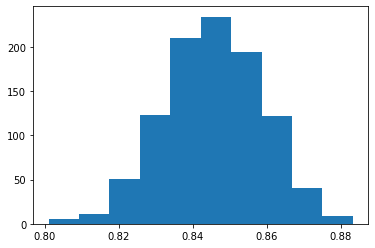

```
95.0 confidence interval 82.0% and 87.1%
```

```python
# plot scores

from matplotlib import pyplot
pyplot.hist(stats)
pyplot.show()
# confidence intervals
alpha = 0.95                             # for 95% confidence
p = ((1.0-alpha)/2.0) * 100              # tail regions on right and left .25 on each side indicated by P value (border)
lower = max(0.0, np.percentile(stats, p))
p = (alpha+((1.0-alpha)/2.0)) * 100
upper = min(1.0, np.percentile(stats, p))
print('%.1f confidence interval %.1f%% and %.1f%%' % (alpha*100, lower*100, upper*100))
```

Thus, at 95% confidence interval the model trained by Gradient Boosting Regression will perfrom accurately between the range of 82% to 87.1%.

##### Random Forest

```python
values = concrete_XY.values
# Number of bootstrap samples to create
n_iterations = 1000
# size of a bootstrap sample
n_size = int(len(concrete_df_z) * 1)

# run bootstrap
# empty list that will hold the scores for each bootstrap iteration
stats = list()
for i in range(n_iterations):
    # prepare train and test sets
    train = resample(values, n_samples=n_size)  # Sampling with replacement
    test = np.array([x for x in values if x.tolist() not in train.tolist()])  # picking rest of the data not considered in sample


     # fit model
    rfTree = RandomForestRegressor(n_estimators=100)
    # fit against independent variables and corresponding target values
    rfTree.fit(train[:,:-1], train[:,-1])
    # Take the target column for all rows in test set

    y_test = test[:,-1]
    # evaluate model
    # predict based on independent variables in the test data
    score = rfTree.score(test[:, :-1] , y_test)
    predictions = rfTree.predict(test[:, :-1])

    stats.append(score)
```

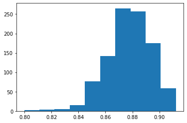

```
95.0 confidence interval 84.4% and 90.5%
```

```python
# plot scores

from matplotlib import pyplot
pyplot.hist(stats)
pyplot.show()
# confidence intervals
alpha = 0.95                             # for 95% confidence
p = ((1.0-alpha)/2.0) * 100              # tail regions on right and left .25 on each side indicated by P value (border)
lower = max(0.0, np.percentile(stats, p))
p = (alpha+((1.0-alpha)/2.0)) * 100
upper = min(1.0, np.percentile(stats, p))
print('%.1f confidence interval %.1f%% and %.1f%%' % (alpha*100, lower*100, upper*100))
```

Thus, at 95% confidence interval the model trained by Random Forest Regression will perfrom accurately between the range of 84.4% and 90.5%.

###### XG Boost Regression

```python
values = concrete_XY.values
# Number of bootstrap samples to create
n_iterations = 1000
# size of a bootstrap sample
n_size = int(len(concrete_df_z) * 1)

# run bootstrap
# empty list that will hold the scores for each bootstrap iteration
stats = list()
for i in range(n_iterations):
    # prepare train and test sets
    train = resample(values, n_samples=n_size)  # Sampling with replacement
    test = np.array([x for x in values if x.tolist() not in train.tolist()])  # picking rest of the data not considered in sample


     # fit model
    rfTree = xgboost.XGBRegressor(n_estimators=100)
    # fit against independent variables and corresponding target values
    rfTree.fit(train[:,:-1], train[:,-1])
    # Take the target column for all rows in test set

    y_test = test[:,-1]
    # evaluate model
    # predict based on independent variables in the test data
    score = rfTree.score(test[:, :-1] , y_test)
    predictions = rfTree.predict(test[:, :-1])

    stats.append(score)
```

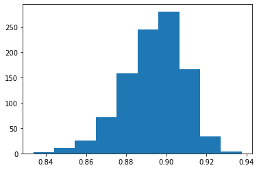

```
95.0 confidence interval 86.2% and 92.0%
```

```python
# plot scores

from matplotlib import pyplot
pyplot.hist(stats)
pyplot.show()
# confidence intervals
alpha = 0.95                             # for 95% confidence
p = ((1.0-alpha)/2.0) * 100              # tail regions on right and left .25 on each side indicated by P value (border)
lower = max(0.0, np.percentile(stats, p))
p = (alpha+((1.0-alpha)/2.0)) * 100
upper = min(1.0, np.percentile(stats, p))
print('%.1f confidence interval %.1f%% and %.1f%%' % (alpha*100, lower*100, upper*100))
```

Thus, at 95% confidence interval the model trained by XG Boost Regression will perfrom accurately between the range of 86.2% to 92%.

Thus, for this activity the best model was the one given by **XG Boost Regression** as it has given the highest accuracy on test data and least RMSE.